# Main Oil Pump Reliability Analysis

# Introduction

### content

1. Executive summary
2. Introduction
   - General Statistic
3. Assumptions
4. Analysis
   - Describtive Analysis.
   - Dominant Failure modes analysis
   - General CR WO frequency
   - Failure rate analysis
   - Pump Reliability
5. Conclusions
6. Recommendations

# Descriptive analysis

Total number of pumps units in analysis is 43 and total number of records is 1465. The map below shows the unit number against site with the volumes of data per each unit. This map shows the fairness of analysis and it is not dominated by one of unit or site. This data is representing 21years of operation. There are some data lost due to hierarchy standardization albeit the available data is enough to build solid statistical conclusions.

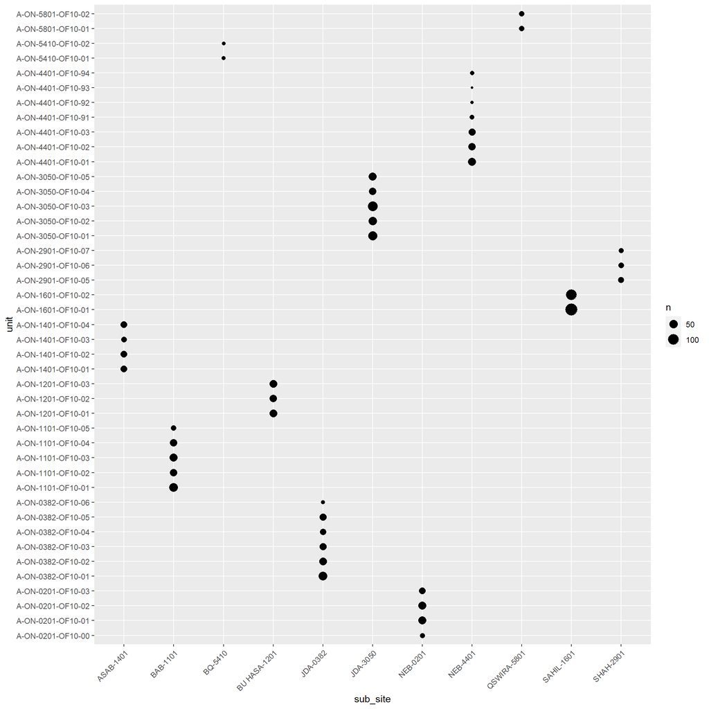

# Dominant Failure Modes Analysis

Dominanat failure modes analysis purpose is to highlight the most problamatic parts and failure modes. Dominate FM charaterizes frequency of CR WOs.

## Dominant Failed Componenet (Failure Class)

Failure class Parito analysis below shows which MOL pumps dominate CR WOs. It is clear for below chart the “PU” (pump) is dominant fail part in mol pump unit then “VA” which is valves. Failure class codes in this chart are presenting old and new codes for failure class.

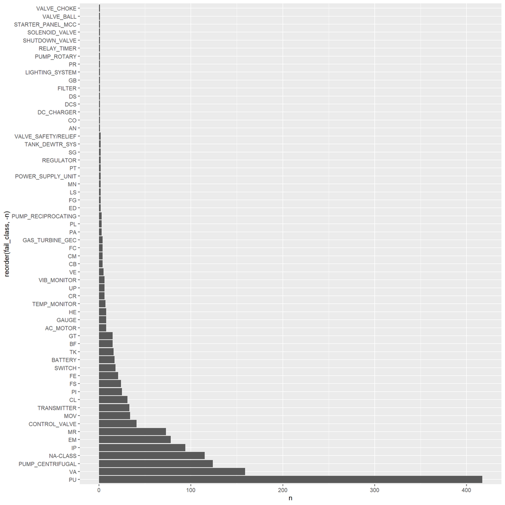

## Dominant Failure Modes

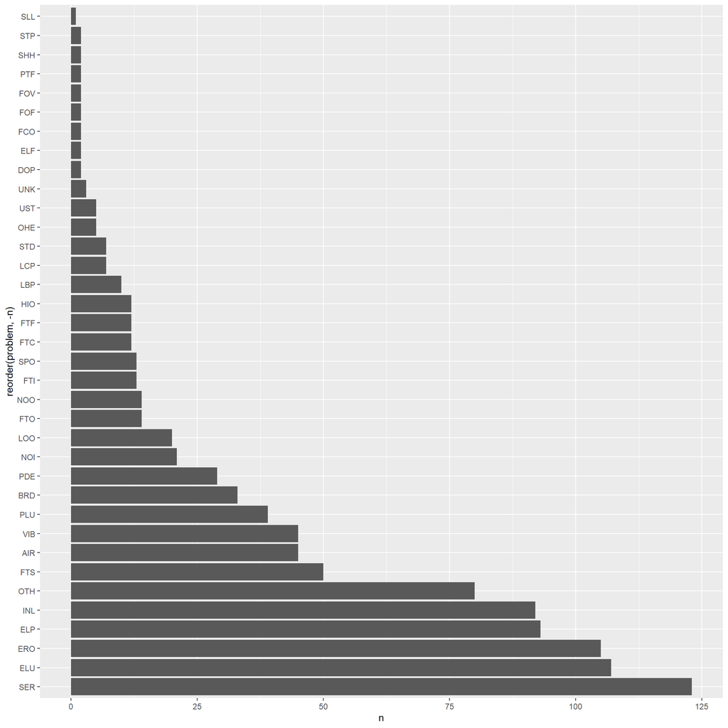

# CR work orders frequency

Corrective work orders load could be easily estimated for future manpower estimation using corrective work order historical data. The parameters that will enable the future forecasting load are frequency of CR WO and average working hours per work order.

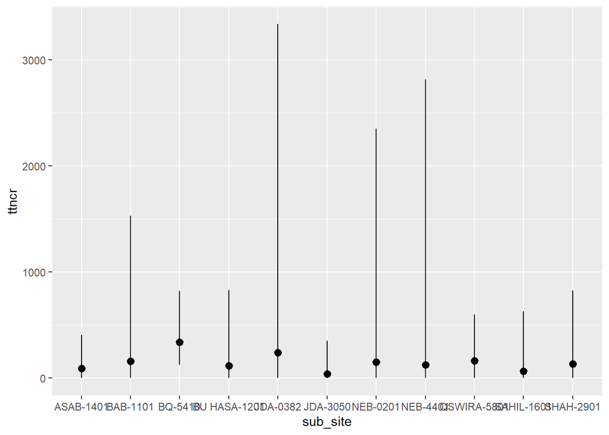

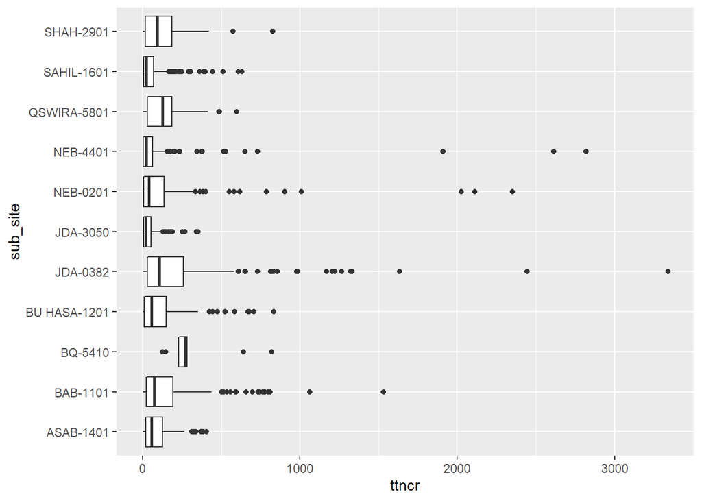

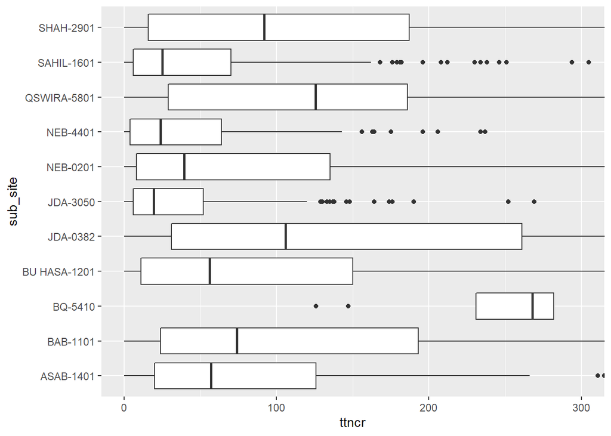

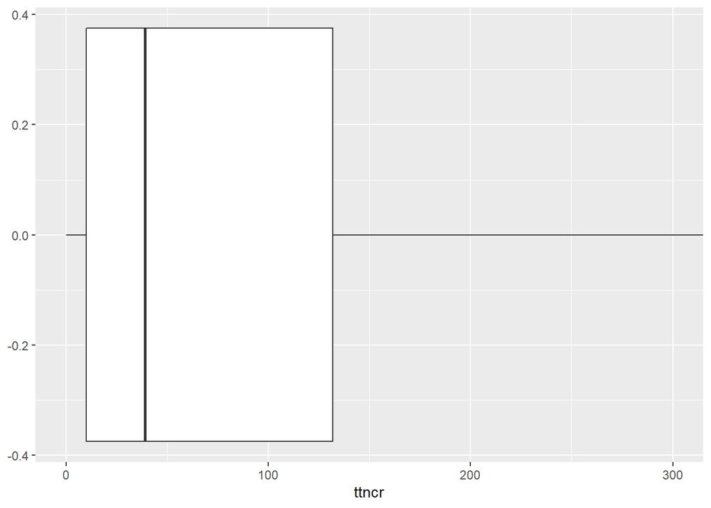

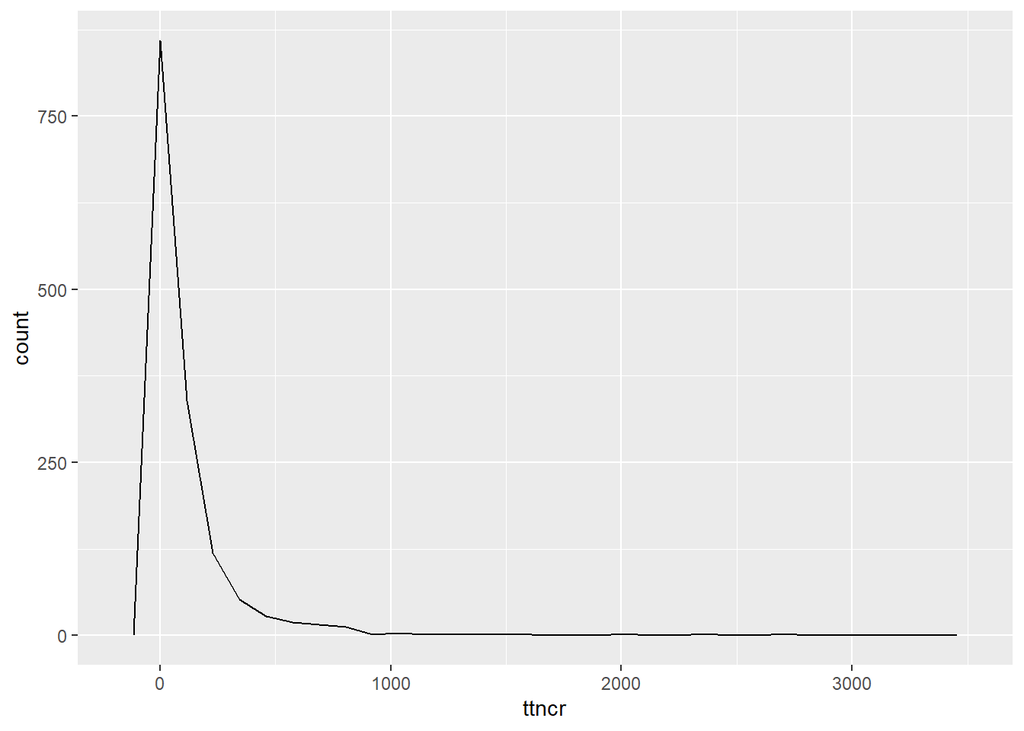

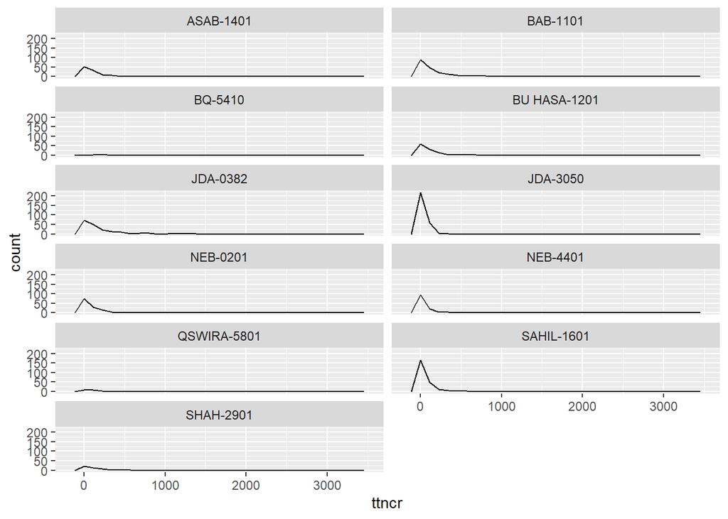

# Mechnical work orders frequency

Corrective work orders load could be easily estimated for future manpower estimation using corrective work order historical data. The parameters that will enable the future forecasting load are frequency of CR WO and average working hours per work order.

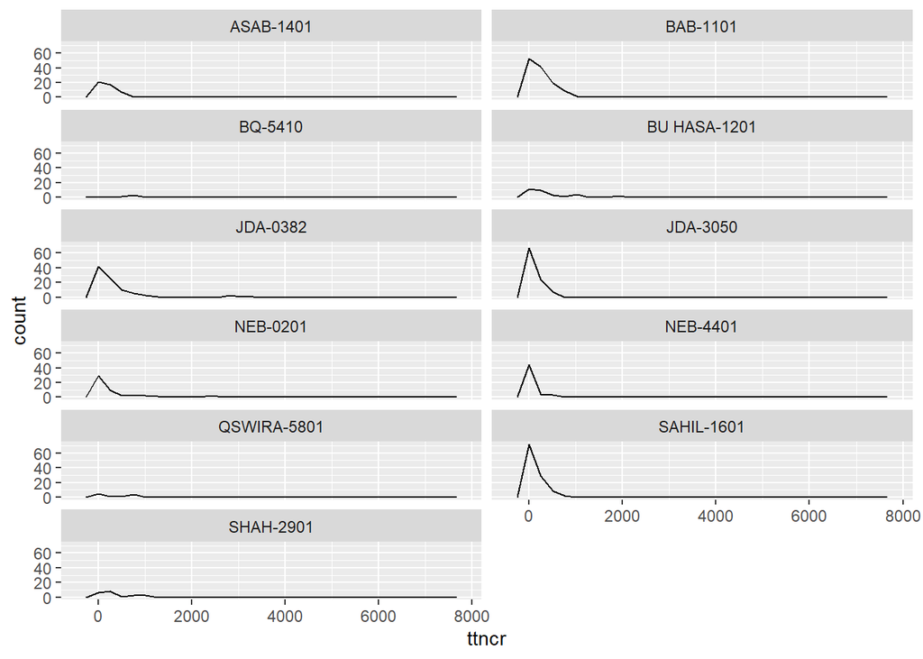

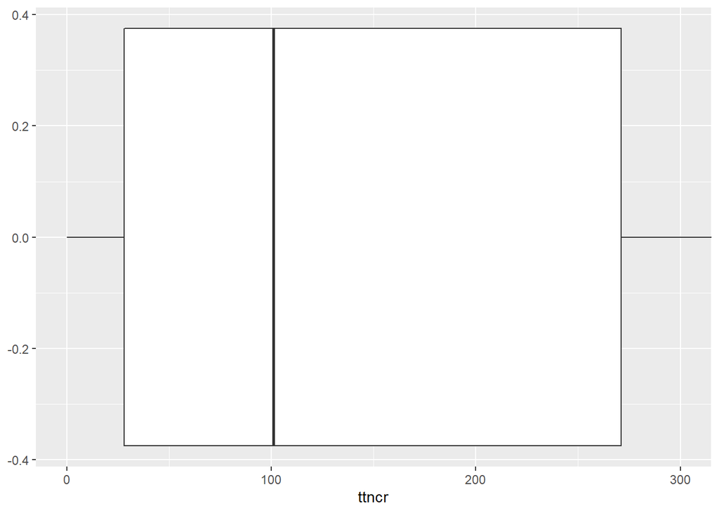

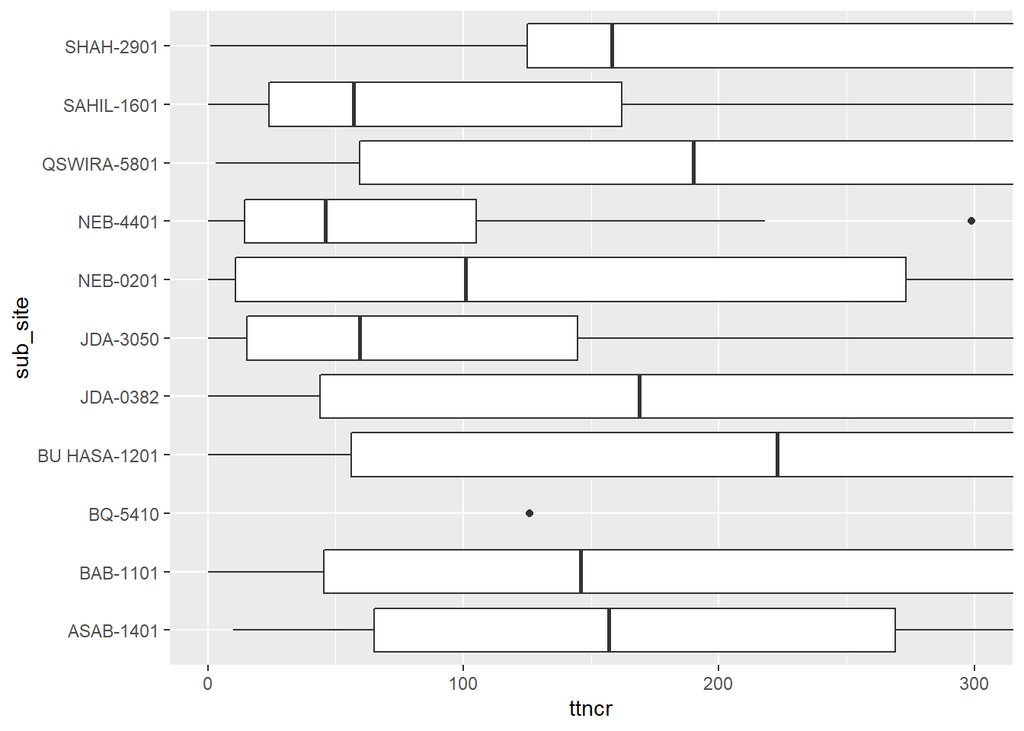